# Assignment Practical Machine Learning

November 2015

# Introduction

The goal of the analysis is to predict the style in which barbell lifts were performed and to predict 20 different test cases. The analysis is based on personal activity data of six individuals collected by fitness devices like Fitbit or Nike FuelBand. The participants performed the barbell lifts in five different styles – one correct and four incorrect ways. The data is provided by Velloso, Bulling, Gellersen, Ugulino and Fuks (2013).

# Model and Resampling

Decision trees are a first candidate for a classification task. However, decision trees tend to overfitting. Random forests are an ensemble learning method that construct different decision trees and thereby provide higher classification accuracy. Random forests correct for decision trees tendency of overfitting. In addition to that, random forests do not require preprocessing of data (e.g. scaling or normalising). These advantages come at the cost of lower interpretability.

The original training data is split into a training (60% percent of the observations) and a test data set. I apply repeated 10-fold cross validation in order to estimate the model performance. This means that the training data is divided into 10 separate random samples, where the model is built on 90 percent of the observations and evaluated on 10 percent of the data each time. This process is repeated five times (5 repetitions of 10-fold cross validation) in order to increase the robustness of the measurements. Finally, the overall performance is obtained by averaging the individual performance measures.

# Analysis

The analyis uses the *caret* package for model training and evaluation. In addition, the *doParallel* package is applied in order to enable parallel computation.

```r
library(caret)
library(doParallel)

cl <- makeCluster(detectCores(), type='PSOCK')
registerDoParallel(cl)
```

Next, I set the working directory and load the initial test and training data set.

```r
wd <- paste0("D:/Benutzer-Profile/marc-andre.nehrkorn-/Documents/_R/",
             "Course 8 - Practical Machine Learning/assignment")
setwd(wd)

test.orig  <- read.table(file = "pml-testing.csv",                # this is for prediction
                         header = TRUE,
                         sep = ",",
                         dec = ".",
                         na.strings = c("NA", "#DIV/0!", ""),
                         as.is=TRUE)
train.orig <- read.table(file = "pml-training.csv",               # this is for training
                         header = TRUE,
                         sep = ",",
                         dec = ".",
                         as.is=TRUE,
                         na.strings = c("NA", "#DIV/0!", ""))
```

In order to facilitate computation, I drop those features that exhibit a substantial number of missing values (although these might be useful for prediction as well). Additionally, I drop index and time stamp columns.

```r
na.count <- apply(train.orig, 2, function(x) sum(is.na(x)))
na.list <- ifelse(na.count>19000, 0, 1)

train.mod.orig <- train.orig[, na.list==1]
test.mod.orig <- test.orig[, na.list==1]

train.mod.orig <- train.mod.orig[, -c(1:7)]
test.mod.orig <- test.mod.orig[, -c(1:7)]
```

As mentioned above, the initial training data set is split into a training and a test data set.

```r
inTrain <- createDataPartition(y = train.mod.orig$classe,
                               p = 0.6,
                               list = FALSE)

training <- train.mod.orig[inTrain,]
testing  <- train.mod.orig[-inTrain,]
```

The following histogram shows that there is substantial variation in exercise styles.

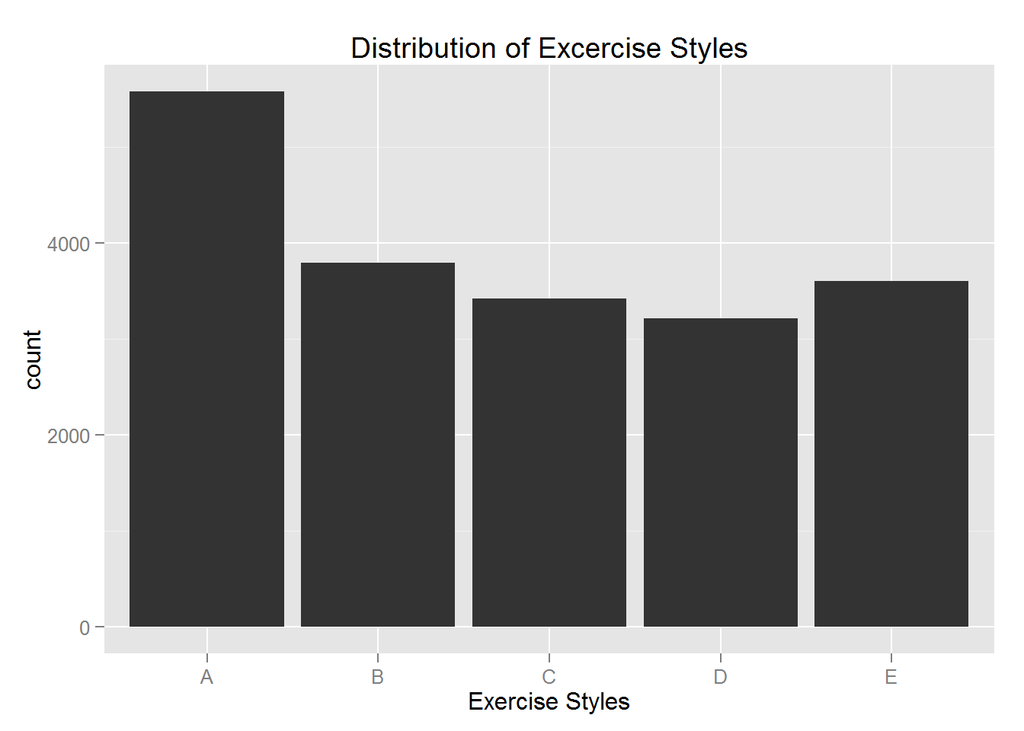

```r
qplot(classe,
      data = train.orig,
      geom = "histogram",
      main = "Distribution of Excercise Styles",
      xlab = "Exercise Styles")
```

Next, a random forest with five times repeated 10-fold cross validation is fitted.

```r
ctrl <- trainControl(method = "repeatedcv",
                     repeats = 5,
                     number = 10)

set.seed(123)
modelFit <- train(classe ~ .,
                  data = training,
                  method = "rf",
                  trControl = ctrl,
                  prox=TRUE)
modelFit
```

```
## Random Forest
##
## 11776 samples
##    52 predictor
##     5 classes: 'A', 'B', 'C', 'D', 'E'
##
## No pre-processing
## Resampling: Cross-Validated (10 fold, repeated 5 times)
## Summary of sample sizes: 10599, 10599, 10598, 10598, 10599, 10598, ...
## Resampling results across tuning parameters:
##
##   mtry  Accuracy   Kappa      Accuracy SD  Kappa SD
##    2    0.9893512  0.9865285  0.003031291  0.003835677
##   27    0.9909985  0.9886124  0.003107142  0.003931770
##   52    0.9820145  0.9772484  0.004671196  0.005908539
##
## Accuracy was used to select the optimal model using  the largest value.
## The final value used for the model was mtry = 27.
```

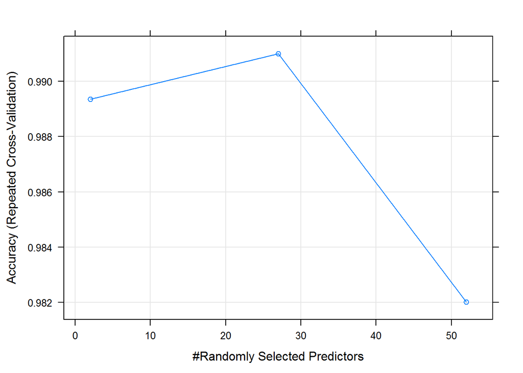

```r
plot(modelFit)
```

```r
modelClasses <- predict(modelFit,
                        newdata = testing)

confusionMatrix(data = modelClasses,
                testing$classe)
```

```
## Confusion Matrix and Statistics
##
##           Reference
## Prediction    A    B    C    D    E
##          A 2226   21    0    0    0
##          B    5 1491   15    0    1
##          C    1    6 1344   17    5
##          D    0    0    9 1265    3
##          E    0    0    0    4 1433
##
## Overall Statistics
##
##                Accuracy : 0.9889
##                  95% CI : (0.9863, 0.9911)
##     No Information Rate : 0.2845
##     P-Value [Acc > NIR] : < 2.2e-16
##
##                   Kappa : 0.986
##  Mcnemar's Test P-Value : NA
##
## Statistics by Class:
##
##                      Class: A Class: B Class: C Class: D Class: E
## Sensitivity            0.9973   0.9822   0.9825   0.9837   0.9938
## Specificity            0.9963   0.9967   0.9955   0.9982   0.9994
## Pos Pred Value         0.9907   0.9861   0.9789   0.9906   0.9972
## Neg Pred Value         0.9989   0.9957   0.9963   0.9968   0.9986
## Prevalence             0.2845   0.1935   0.1744   0.1639   0.1838
## Detection Rate         0.2837   0.1900   0.1713   0.1612   0.1826
## Detection Prevalence   0.2864   0.1927   0.1750   0.1628   0.1832
## Balanced Accuracy      0.9968   0.9894   0.9890   0.9909   0.9966
```

The confusion matrix shows that some exercises have been misclassified but that the overall (out of sample) accuracy is still pretty high (0.99). The results might be further improved by allowing for more than three values of the tuning parameter.

# Sources

Velloso, E.; Bulling, A.; Gellersen, H.; Ugulino, W.; Fuks, H. Qualitative Activity Recognition of Weight Lifting Exercises. Proceedings of 4th International Conference in Cooperation with SIGCHI (Augmented Human ’13) . Stuttgart, Germany: ACM SIGCHI, 2013.